# Reproducible Research: Peer Assessment 1

## Loading and preprocessing the data

The subsequent analysis will involve the data aggregated by day and also, separately, by interval, so after loading the data, let’s do the aggregations. We have to be careful to omit the NA data in order to do subsequent steps. Also, converting the date column to type Date ensures that we can do a nice time series plot later.

```r
library(dplyr)
```

```r
df <- read.csv("activity.csv")
df <- mutate(df, date=as.Date(date, format="%Y-%m-%d"));
dfclean <- na.omit(df)
daily <- group_by(dfclean, date)
byInterval <- group_by(dfclean, interval)
```

## What is mean total number of steps taken per day?

Let’s first plot the histogram of daily total steps.

```r
library(ggplot2)
```

```
## stat_bin: binwidth defaulted to range/30. Use 'binwidth = x' to adjust this.
```

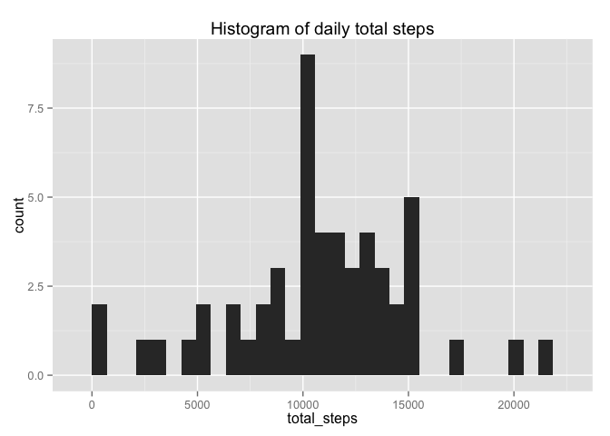

```r
totals <- daily %>% summarize(total_steps=sum(steps))
qplot(total_steps, data=totals, main="Histogram of daily total steps");
```

Measuring by eye, it appears that this person would most often take between 10,000 and 15,000 steps in a day, since those are the values that contain most of the histogram.

Next, let’s find the mean and median of the total number of daily steps. Let’s see what the average daily total is for this person.

```r
mean(totals$total_steps)
```

```
## [1] 10766.19
```

```r
median(totals$total_steps)
```

```
## [1] 10765
```

This correspondes with my original estimate above evaluating the histogram by eye. That the mean and median are very close means that the distribution is not very skewed, which also matches the histogram above.

## What is the average daily activity pattern?

The following R code and plot shows the average number of steps in each time interval, taken across all days. This reveals that there is a peak of activity somewhere between the 750th and 1000th minute.

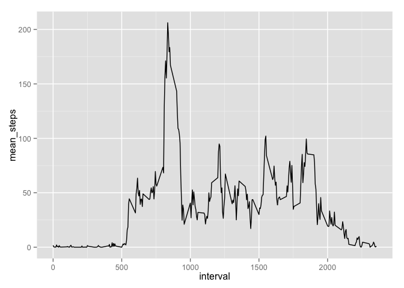

```r
totInts <- byInterval %>% summarize(mean_steps=mean(steps))
qplot(data=totInts, interval, y=mean_steps, geom="line")
```

```r
intervalWithMaxActivity <- totInts$interval[which.max(totInts$mean_steps)]
```

## Imputing missing values

Next let’s check on what kind of impact the NAs are having on our results. The total number of NAs is calculated below, for each variable in the original data set.

```r
sum(is.na(df$steps))
```

```
## [1] 2304
```

```r
sum(is.na(df$date))
```

```
## [1] 0
```

```r
sum(is.na(df$interval))
```

```
## [1] 0
```

So it appears that only the steps variable has missing values, and a large number of them.

One way to remove the NAs is by replacing each one with the average in its interval. This would be a good method if this person were very consistent in his/her daily activities across all days. Let’s do that below.

I use ‘match’ to produce the indices in the mean_steps that have the same interval as in df[naInds,]. Then I use those indices to replace the NAs with the mean_step for that interval.

```r
totInts$intSteps <- sapply(totInts$mean_steps, round)
naInds <- is.na(df$steps)

intInds <- match(df[naInds,]$interval, totInts$interval)
dfReplace <- mutate(df, filled_steps=steps)
dfReplace$filled_steps[naInds] = totInts$mean_steps[intInds]
sum(is.na(dfReplace$filled_steps))
```

```
## [1] 0
```

Having filled in the NAs with averages, now let’s aggregate by date, then plot the daily totals. The graph shows that the distribution is not very different with the invalid data filled in with means.

```
## stat_bin: binwidth defaulted to range/30. Use 'binwidth = x' to adjust this.
```

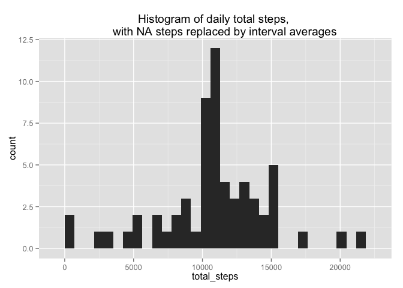

```r
dailyReplace <- dfReplace %>% group_by(date)
totalsReplace <- dailyReplace %>% summarize(total_steps=sum(filled_steps))
qplot(total_steps, data=totalsReplace, main="Histogram of daily total steps,
      with NA steps replaced by interval averages");
```

Next, let’s find the mean and median of the total number of daily steps. The mean and median are very similar to before, which is a good thing. We wouldn’t want our filling of invalid data to have much influence on the population statistics.

```r
mean(totalsReplace$total_steps)
```

```
## [1] 10766.19
```

```r
median(totalsReplace$total_steps)
```

```
## [1] 10766.19
```

## Are there differences in activity patterns between weekdays and weekends?

By making a factor variable for whether the date is a weekday or weekend, we can compare the person’s mean behavior in both situations. After grouping by weekend/weekday as well as by interval, and generating another time series of his/her behavior throughout the day, we see that on the weekend, there is much less activity before the 750th minute of the day. The peak around minute 800 is still there but is much lower (around 150 steps vs. over 200), and there is more activity in the middle of the day than in the weekday case. This might indicate, for example, that this person has a desk job, but is fairly active during the weekend.

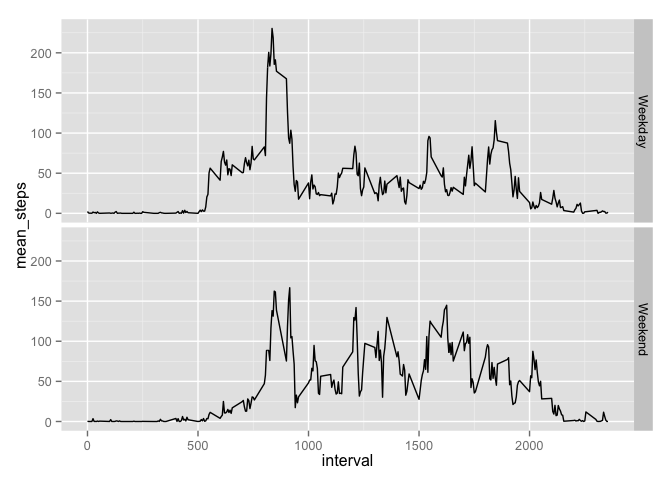

```r
day = weekdays(dfReplace$date)
dfReplace <- mutate(dfReplace, day=as.factor(ifelse((day=="Saturday") |
                                                     (day=="Sunday"), "Weekend",
                                                 "Weekday")))
repByInterval <- dfReplace %>% group_by(day, interval)
repTotInts <- repByInterval %>% summarize(mean_steps=mean(filled_steps))
qplot(data=repTotInts, interval, y=mean_steps, geom="line", facets=day~.)
```